title: “Notes 2 - Statistical Inference” author: “Linda Kukolich” date: “February 10, 2015” output: html_document

*These notes are a copy of the original slides*

## The variance

- The variance of a random variable is a measure of *spread*
- If $X$ is a random variable with mean $\mu$, the variance of $X$ is defined as

$Var(X) = E[(X - \mu)^2] = E[X^2] - E[X]^2$

- The expected (squared) distance from the mean
- Densities with a higher variance are more spread out than densities with a lower variance
- The square root of the variance is called the **standard deviation**
- The standard deviation has the same units as $X$

## Example

- What’s the variance from the result of a toss of a die?
- $E[X] = 3.5$
- $E[X^2] = 1 ^ 2 \times \frac{1}{6} + 2 ^ 2 \times \frac{1}{6} + 3 ^ 2 \times \frac{1}{6} + 4 ^ 2 \times \frac{1}{6} + 5 ^ 2 \times \frac{1}{6} + 6 ^ 2 \times \frac{1}{6} = 15.17$
- $Var(X) = E[X^2] - E[X]^2 \approx 2.92$

## Example

- What’s the variance from the result of the toss of a coin with probability of heads (1) of $p$?
- $E[X] = 0 \times (1 - p) + 1 \times p = p$
- $E[X^2] = E[X] = p$

$Var(X) = E[X^2] - E[X]^2 = p - p^2 = p(1 - p)$

## Distributions with increasing variance

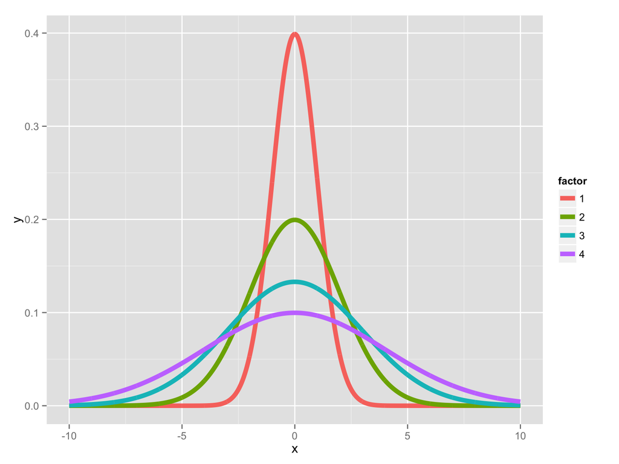

## The sample variance

- The sample variance is $S^2 = \frac{\sum_{i=1} (X_i - \bar X)^2}{n-1}$ (almost, but not quite, the average squared deviation from the sample mean)
- It is also a random variable
- It has an associate population distribution
- Its expected value is the population variance
- Its distribution gets more concentrated around the population variance with more data
- Its square root is the sample standard deviation

## Simulation experiment

### Simulating from a population with variance 1

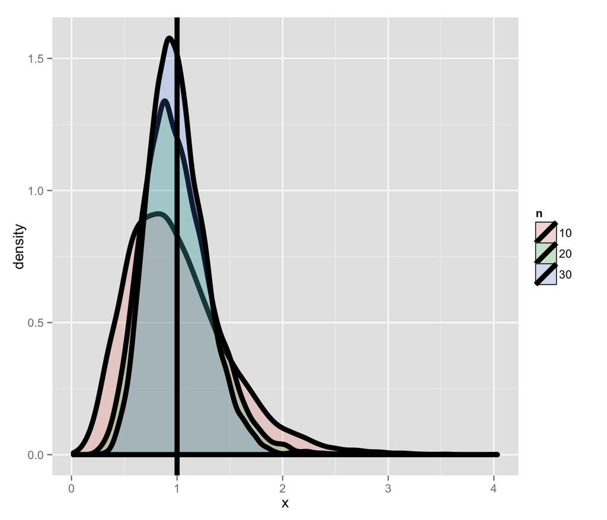

## Variances of x die rolls

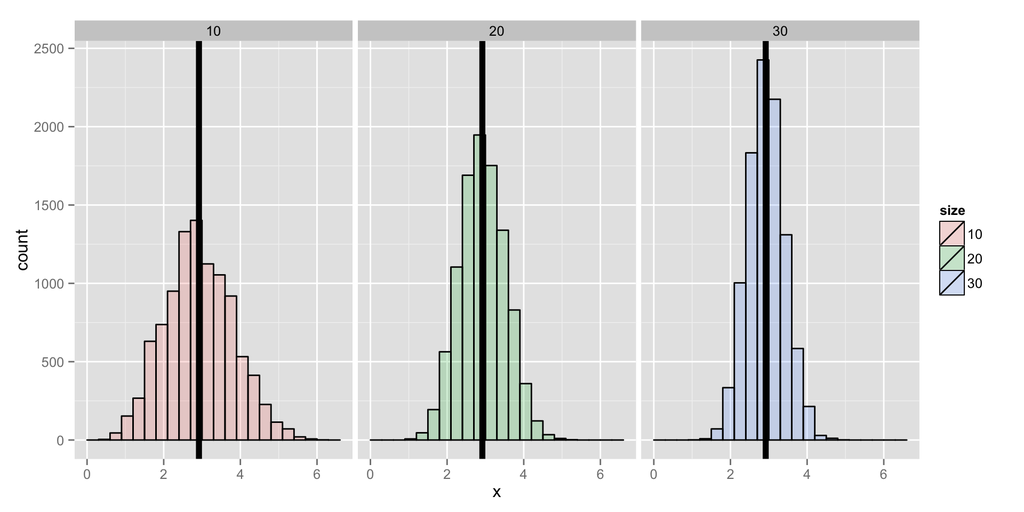

## Recall the mean

- Recall that the average of random sample from a population is itself a random variable
- We know that this distribution is centered around the population mean, $E[\bar X] = \mu$
- We also know what its variance is $Var(\bar X) = \sigma^2 / n$
- This is very useful, since we don’t have repeat sample means to get its variance; now we know how it relates to the population variance
- **We call the standard deviation of a statistic a standard error**

## To summarize

- The sample variance, $S^2$, estimates the population variance, $\sigma^2$
- The distribution of the sample variance is centered around $\sigma^2$
- The the variance of sample mean is $\sigma^2 / n$
- Its logical estimate is $s^2 / n$
- The logical estimate of the standard error is $s / \sqrt{n}$
- $s$, the standard deviation, talks about how variable the population is
- $s/\sqrt{n}$, the standard error, talks about how variable averages of random samples of size $n$ from the population are

## Simulation example

Standard normals have variance 1; means of $n$ standard normals have standard deviation $1/\sqrt{n}$

```r
nosim <- 1000
n <- 10
sd(apply(matrix(rnorm(nosim * n), nosim), 1, mean))
```

```
## [1] 0.3104718
```

```r
1 / sqrt(n)
```

```
## [1] 0.3162278
```

## Simulation example

Standard uniforms have variance $1/12$; means of random samples of $n$ uniforms have sd $1/\sqrt{12 \times n}$

```r
nosim <- 1000
n <- 10
sd(apply(matrix(runif(nosim * n), nosim), 1, mean))
```

```
## [1] 0.09342885
```

```r
1 / sqrt(12 * n)
```

```
## [1] 0.09128709
```

## Simulation example

Poisson(4) have variance $4$; means of random samples of $n$ Poisson(4) have sd $2/\sqrt{n}$

```r
nosim <- 1000
n <- 10
sd(apply(matrix(rpois(nosim * n, 4), nosim), 1, mean))
```

```
## [1] 0.6172129
```

```r
2 / sqrt(n)
```

```
## [1] 0.6324555
```

## Simulation example

Fair coin flips have variance $0.25$; means of random samples of $n$ coin flips have sd $1 / (2 \sqrt{n})$

```r
nosim <- 1000
n <- 10
sd(apply(matrix(sample(0 : 1, nosim * n, replace = TRUE),
                nosim), 1, mean))
```

```
## [1] 0.1611793
```

```r
1 / (2 * sqrt(n))
```

```
## [1] 0.1581139
```

## Data example

```r
library(UsingR); data(father.son);
x <- father.son$sheight
n<-length(x)
```

## Plot of the son’s heights

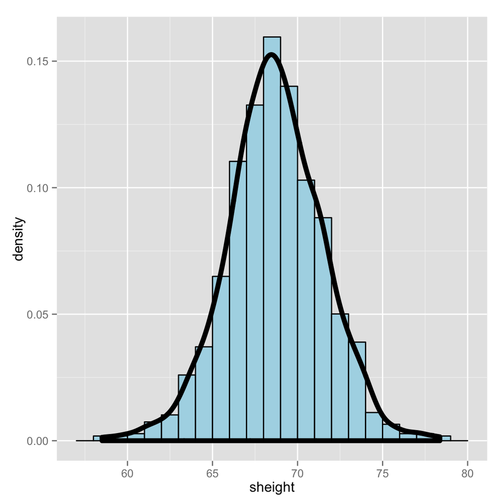

## Let’s interpret these numbers

```r
round(c(var(x), var(x) / n, sd(x), sd(x) / sqrt(n)),2)
```

```
## [1] 7.92 0.01 2.81 0.09
```

```r
# variance (in^2), se^2, standard deviation (in), standard error (standard deviation in the distributon of averages of n children's heights)
```

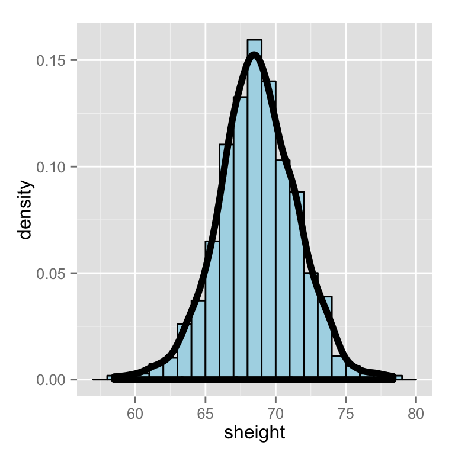

## Summarizing what we know about variances

- The sample variance estimates the population variance
- The distribution of the sample variance is centered at what its estimating
- It gets more concentrated around the population variance with larger sample sizes
- The variance of the sample mean is the population variance divided by $n$
- The square root is the standard error
- It turns out that we can say a lot about the distribution of averages from random samples, even though we only get one to look at in a given data set

# Common distributions

## The Bernoulli distribution

- The **Bernoulli distribution** arises as the result of a binary outcome
- Bernoulli random variables take (only) the values 1 and 0 with probabilities of (say) $p$ and $1-p$ respectively
- The PMF for a Bernoulli random variable $X$ is $P(X = x) = p^x (1 - p)^{1 - x}$
- The mean of a Bernoulli random variable is $p$ and the variance is $p(1 - p)$
- If we let $X$ be a Bernoulli random variable, it is typical to call $X=1$ as a “success” and $X=0$ as a “failure”

## Binomial trials

- The *binomial random variables* are obtained as the sum of iid Bernoulli trials
- In specific, let $X_1,\ldots,X_n$ be iid Bernoulli$(p)$; then $X = \sum_{i=1}^n X_i$ is a binomial random variable
- The binomial mass function is $P(X = x) = \left( \begin{array}{c} n \\ x \end{array} \right) p^x(1 - p)^{n-x}$ for $x=0,\ldots,n$

## Choose

- Recall that the notation $\left( \begin{array}{c} n \\ x \end{array} \right) = \frac{n!}{x!(n-x)!}$ (read “$n$ choose $x$”) counts the number of ways of selecting $x$ items out of $n$ without replacement disregarding the order of the items

$\left( \begin{array}{c} n \\ 0 \end{array} \right) = \left( \begin{array}{c} n \\ n \end{array} \right) = 1$

## Example

- Suppose a friend has $8$ children (oh my!), $7$ of which are girls and none are twins
- If each gender has an independent $50$% probability for each birth, what’s the probability of getting $7$ or more girls out of $8$ births?

${8 \choose 7} .5^{7}(1-.5)^{1} + {8 \choose 8} .5^{8}(1-.5)^{0} \approx 0.04$

```r
choose(8, 7) * .5 ^ 8 + choose(8, 8) * .5 ^ 8
```

```
## [1] 0.03515625
```

```r
pbinom(6, size = 8, prob = .5, lower.tail = FALSE)
```

```
## [1] 0.03515625
```

## The normal distribution

- A random variable is said to follow a **normal** or **Gaussian** distribution with mean $\mu$ and variance $\sigma^2$ if the associated density is $(2\pi \sigma^2)^{-1/2}e^{-(x - \mu)^2/2\sigma^2}$ If $X$ a RV with this density then $E[X] = \mu$ and $Var(X) = \sigma^2$
- We write $X\sim \mbox{N}(\mu, \sigma^2)$
- When $\mu = 0$ and $\sigma = 1$ the resulting distribution is called **the standard normal distribution**
- Standard normal RVs are often labeled $Z$

## The standard normal distribution with reference lines

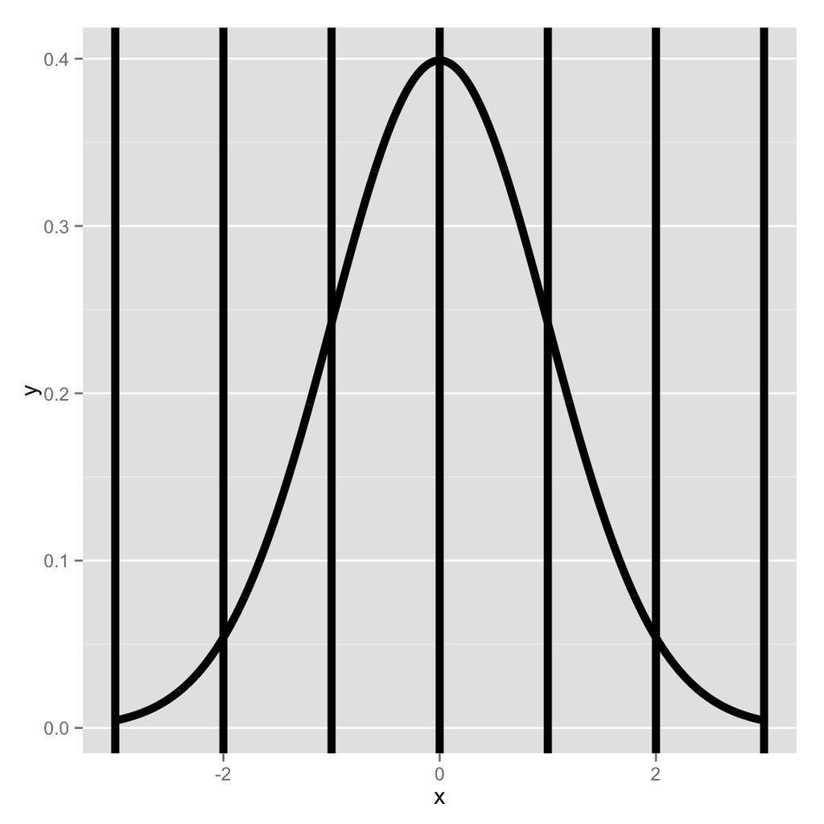

## Facts about the normal density

If $X \sim \mbox{N}(\mu,\sigma^2)$ then $Z = \frac{X -\mu}{\sigma} \sim N(0, 1)$

If $Z$ is standard normal $X = \mu + \sigma Z \sim \mbox{N}(\mu, \sigma^2)$

## More facts about the normal density

1. Approximately $68\%$, $95\%$ and $99\%$ of the normal density lies within $1$, $2$ and $3$ standard deviations from the mean, respectively
2. $-1.28$, $-1.645$, $-1.96$ and $-2.33$ are the $10^{th}$, $5^{th}$, $2.5^{th}$ and $1^{st}$ percentiles of the standard normal distribution respectively
3. By symmetry, $1.28$, $1.645$, $1.96$ and $2.33$ are the $90^{th}$, $95^{th}$, $97.5^{th}$ and $99^{th}$ percentiles of the standard normal distribution respectively

## Question

- What is the $95^{th}$ percentile of a $N(\mu, \sigma^2)$ distribution?
- Quick answer in R `qnorm(.95, mean = mu, sd = sd)`
- Or, because you have the standard normal quantiles memorized and you know that 1.645 is the 95th percentile you know that the answer has to be $\mu + \sigma 1.645$
- (In general $\mu + \sigma z_0$ where $z_0$ is the appropriate standard normal quantile)

## Question

- What is the probability that a $\mbox{N}(\mu,\sigma^2)$ RV is larger than $x$?

‘pnorm(x, mean=mu, sd = sigma, lower.tail=FALSE)` OR ’1- pnorm(x, mean=mu, sd=sigma)’ $\frac{x - \mu}{\sigma}$

## Example

Assume that the number of daily ad clicks for a company is (approximately) normally distributed with a mean of 1020 and a standard deviation of 50. What’s the probability of getting more than 1,160 clicks in a day?

## Example

Assume that the number of daily ad clicks for a company is (approximately) normally distributed with a mean of 1020 and a standard deviation of 50. What’s the probability of getting more than 1,160 clicks in a day?

It’s not very likely, 1,160 is 2.8 standard deviations from the mean

```r
pnorm(1160, mean = 1020, sd = 50, lower.tail = FALSE)
```

```
## [1] 0.00255513
```

```r
pnorm((1160-1020)/50, lower.tail = FALSE)
```

```
## [1] 0.00255513
```

## Example

Assume that the number of daily ad clicks for a company is (approximately) normally distributed with a mean of 1020 and a standard deviation of 50. What number of daily ad clicks would represent the one where 75% of days have fewer clicks (assuming days are independent and identically distributed)?

## Example

Assume that the number of daily ad clicks for a company is (approximately) normally distributed with a mean of 1020 and a standard deviation of 50. What number of daily ad clicks would represent the one where 75% of days have fewer clicks (assuming days are independent and identically distributed)?

We know 50% is at 1020. We know that 1 sigma = 68%, so 16% lies above 1 sigma (1020 + 50) (the 84% mark)

```r
qnorm(0.75, mean = 1020, sd = 50)
```

```
## [1] 1053.724
```

## The Poisson distribution

- Used to model counts
- The Poisson mass function is $P(X = x; \lambda) = \frac{\lambda^x e^{-\lambda}}{x!}$ for $x=0,1,\ldots$
- The mean of this distribution is $\lambda$
- The variance of this distribution is $\lambda$
- Notice that $x$ ranges from $0$ to $\infty$

## Some uses for the Poisson distribution

- Modeling count data
  - model unbounded count data
- Modeling event-time or survival data
  - Whether someone has recurrance of symptoms in a cancer study. If someone hasn’t shown symptoms within the time of study, that is not the same as remission.
- Modeling contingency tables
  - counts of something like hair color by race
- Approximating binomials when $n$ is large and $p$ is small

## Rates and Poisson random variables

- Poisson random variables are used to model rates
- $X \sim Poisson(\lambda t)$ where
- $\lambda = E[X / t]$ is the expected count per unit of time
- $t$ is the total monitoring time

## Example

The number of people that show up at a bus stop is Poisson with a mean of $2.5$ per hour.

If watching the bus stop for 4 hours, what is the probability that $3$ or fewer people show up for the whole time?

```r
ppois(3, lambda = 2.5 * 4)
```

```
## [1] 0.01033605
```

## Poisson approximation to the binomial

- When $n$ is large and $p$ is small the Poisson distribution is an accurate approximation to the binomial distribution
- Notation
- $X \sim \mbox{Binomial}(n, p)$
- $\lambda = n p$
- $n$ gets large
- $p$ gets small

## Example, Poisson approximation to the binomial

We flip a coin with success probablity $0.01$ five hundred times.

What’s the probability of 2 or fewer successes?

```r
pbinom(2, size = 500, prob = .01)
```

```
## [1] 0.1233858
```

```r
ppois(2, lambda=500 * .01)
```

```
## [1] 0.124652
```

## Asymptotics

- Asymptotics is the term for the behavior of statistics as the sample size (or some other relevant quantity) limits to infinity (or some other relevant number)
- (Asymptopia is my name for the land of asymptotics, where everything works out well and there’s no messes. The land of infinite data is nice that way.)
- Asymptotics are incredibly useful for simple statistical inference and approximations
- (Not covered in this class) Asymptotics often lead to nice understanding of procedures
- Asymptotics generally give no assurances about finite sample performance
- Asymptotics form the basis for frequency interpretation of probabilities (the long run proportion of times an event occurs)

## Limits of random variables

- Fortunately, for the sample mean there’s a set of powerful results
- These results allow us to talk about the large sample distribution of sample means of a collection of $iid$ observations
- The first of these results we inuitively know
- It says that the average limits to what its estimating, the population mean
- It’s called the Law of Large Numbers
- Example $\bar X_n$ could be the average of the result of $n$ coin flips (i.e. the sample proportion of heads)
  - As we flip a fair coin over and over, it evetually converges to the true probability of a head The LLN forms the basis of frequency style thinking

## Law of large numbers in action

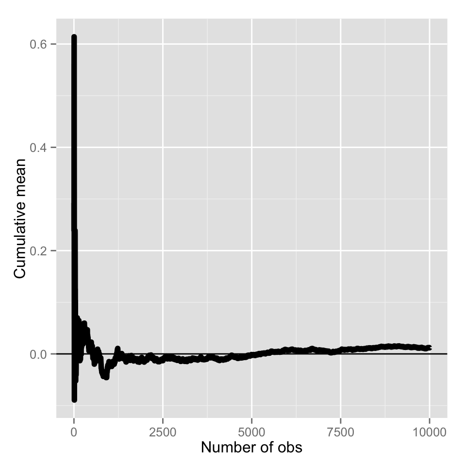

```r
n <- 10000; means <- cumsum(rnorm(n)) / (1  : n); library(ggplot2)
g <- ggplot(data.frame(x = 1 : n, y = means), aes(x = x, y = y))
g <- g + geom_hline(yintercept = 0) + geom_line(size = 2)
g <- g + labs(x = "Number of obs", y = "Cumulative mean")
g
```

## Law of large numbers in action, coin flip

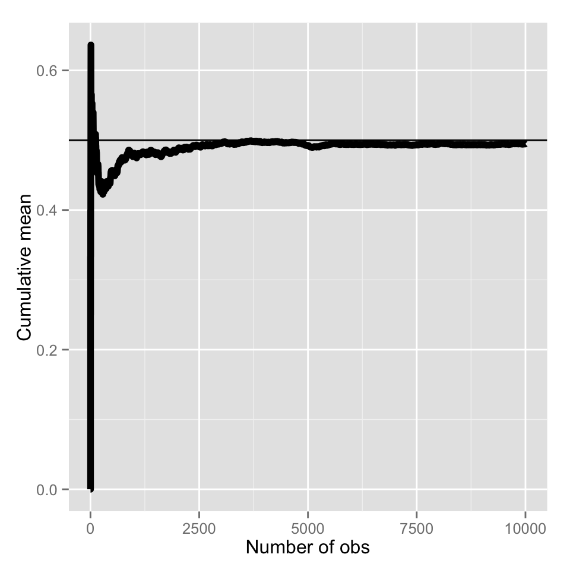

```r
means <- cumsum(sample(0 : 1, n , replace = TRUE)) / (1  : n)
g <- ggplot(data.frame(x = 1 : n, y = means), aes(x = x, y = y))
g <- g + geom_hline(yintercept = 0.5) + geom_line(size = 2)
g <- g + labs(x = "Number of obs", y = "Cumulative mean")
g
```

## Discussion

- An estimator is **consistent** if it converges to what you want to estimate
- The LLN says that the sample mean of iid sample is consistent for the population mean
- Typically, good estimators are consistent; it’s not too much to ask that if we go to the trouble of collecting an infinite amount of data that we get the right answer
- The sample variance and the sample standard deviation of iid random variables are consistent as well

## The Central Limit Theorem

- The **Central Limit Theorem** (CLT) is one of the most important theorems in statistics
- For our purposes, the CLT states that the distribution of averages of iid variables (properly normalized) becomes that of a standard normal as the sample size increases
- The CLT applies in an endless variety of settings
- The result is that $\frac{\bar X_n - \mu}{\sigma / \sqrt{n}}= \frac{\sqrt n (\bar X_n - \mu)}{\sigma} = \frac{\mbox{Estimate} - \mbox{Mean of estimate}}{\mbox{Std. Err. of estimate}}$ has a distribution like that of a standard normal for large $n$.
- (Replacing the standard error by its estimated value doesn’t change the CLT)
- The useful way to think about the CLT is that $\bar X_n$ is approximately $N(\mu, \sigma^2 / n)$ (population mean and standard error of the mean)

## Example

- Simulate a standard normal random variable by rolling $n$ (six sided)
- Let $X_i$ be the outcome for die $i$
- Then note that $\mu = E[X_i] = 3.5$
- $Var(X_i) = 2.92$
- SE $\sqrt{2.92 / n} = 1.71 / \sqrt{n}$
- Lets roll $n$ dice, take their mean, subtract off 3.5, and divide by $1.71 / \sqrt{n}$ and repeat this over and over

## Result of our die rolling experiment

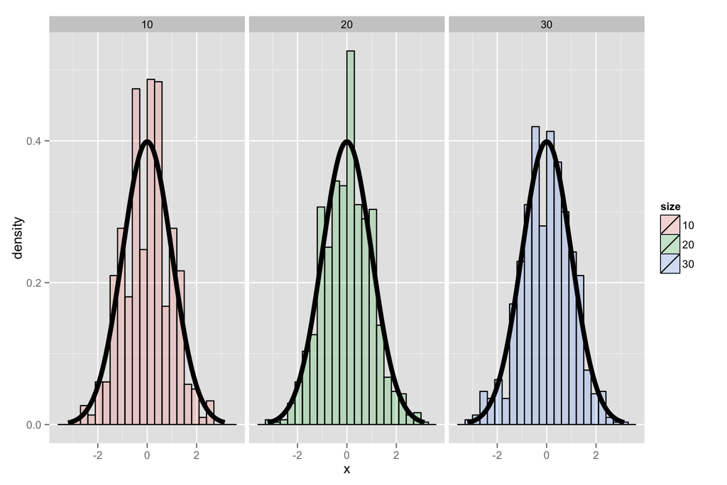

## Coin CLT

- Let $X_i$ be the $0$ or $1$ result of the $i^{th}$ flip of a possibly unfair coin
- The sample proportion, say $\hat p$, is the average of the coin flips
- $E[X_i] = p$ and $Var(X_i) = p(1-p)$
- Standard error of the mean is $\sqrt{p(1-p)/n}$
- Then $\frac{\hat p - p}{\sqrt{p(1-p)/n}}$ will be approximately normally distributed
- Let’s flip a coin $n$ times, take the sample proportion of heads, subtract off .5 and multiply the result by $2 \sqrt{n}$ (divide by $1/(2 \sqrt{n})$)

## Simulation results

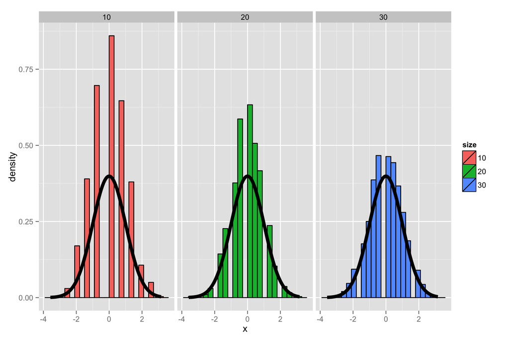

## Simulation results, $p = 0.9$

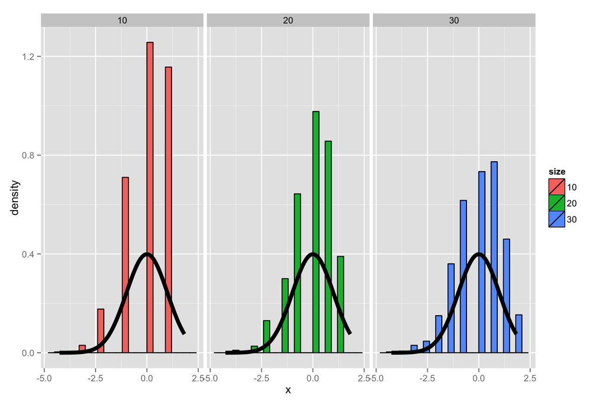

## Galton’s quincunx

```r
if (!file.exists("fig")){
    dir.create("fig")
}
if (!file.exists("fig/quincunx.png")) {
    download.file("http://en.wikipedia.org/wiki/Bean_machine#mediaviewer/File:Quincunx_(Galton_Box)_-_Galton_1889_diagram.png", "fig/quincunx.png")
}
```

http://en.wikipedia.org/wiki/Bean_machine#mediaviewer/File:Quincunx_(Galton_Box)_-_Galton_1889_diagram.png

[figure not shown]

## Confidence intervals

- According to the CLT, the sample mean, $\bar X$, is approximately normal with mean $\mu$ and sd $\sigma / \sqrt{n}$
- $\mu + 2 \sigma /\sqrt{n}$ is pretty far out in the tail (only 2.5% of a normal being larger than 2 sds in the tail)
- Similarly, $\mu - 2 \sigma /\sqrt{n}$ is pretty far in the left tail (only 2.5% chance of a normal being smaller than 2 sds in the tail)
- So the probability $\bar X$ is bigger than $\mu + 2 \sigma / \sqrt{n}$ or smaller than $\mu - 2 \sigma / \sqrt{n}$ is 5%
  - Or equivalently, the probability of being between these limits is 95%
- The quantity $\bar X \pm 2 \sigma /\sqrt{n}$ is called a 95% interval for $\mu$
- The 95% refers to the fact that if one were to repeatly get samples of size $n$, about 95% of the intervals obtained would contain $\mu$
- The 97.5th quantile is 1.96 (so I rounded to 2 above)
- 90% interval you want (100 - 90) / 2 = 5% in each tail
- So you want the 95th percentile (1.645)

## Give a confidence interval for the average height of sons

in Galton’s data

```r
library(UsingR);data(father.son); x <- father.son$sheight
(mean(x) + c(-1, 1) * qnorm(.975) * sd(x) / sqrt(length(x))) / 12
```

```
## [1] 5.709670 5.737674
```

## Sample proportions

- In the event that each $X_i$ is $0$ or $1$ with common success probability $p$ then $\sigma^2 = p(1 - p)$
- The interval takes the form $\hat p \pm z_{1 - \alpha/2} \sqrt{\frac{p(1 - p)}{n}}$
- Replacing $p$ by $\hat p$ in the standard error results in what is called a Wald confidence interval for $p$
- For 95% intervals $\hat p \pm \frac{1}{\sqrt{n}}$ is a quick CI estimate for $p$

## Example

- Your campaign advisor told you that in a random sample of 100 likely voters, 56 intend to vote for you.
- Can you relax? Do you have this race in the bag?
- Without access to a computer or calculator, how precise is this estimate?
- `1/sqrt(100)=0.1` so a back of the envelope calculation gives an approximate 95% interval of `(0.46, 0.66)`
- Not enough for you to relax, better go do more campaigning!
- Rough guidelines, 100 for 1 decimal place, 10,000 for 2, 1,000,000 for 3.

```r
round(1 / sqrt(10 ^ (1 : 6)), 3)
```

```
## [1] 0.316 0.100 0.032 0.010 0.003 0.001
```

## Binomial interval

```r
.56 + c(-1, 1) * qnorm(.975) * sqrt(.56 * .44 / 100)
```

```
## [1] 0.4627099 0.6572901
```

```r
binom.test(56, 100)$conf.int
```

```
## [1] 0.4571875 0.6591640
## attr(,"conf.level")
## [1] 0.95
```

## Simulation

```r
n <- 20; pvals <- seq(.1, .9, by = .05); nosim <- 1000
coverage <- sapply(pvals, function(p){
  phats <- rbinom(nosim, prob = p, size = n) / n
  ll <- phats - qnorm(.975) * sqrt(phats * (1 - phats) / n)
  ul <- phats + qnorm(.975) * sqrt(phats * (1 - phats) / n)
  mean(ll < p & ul > p)
})
```

## Plot of the results (not so good)

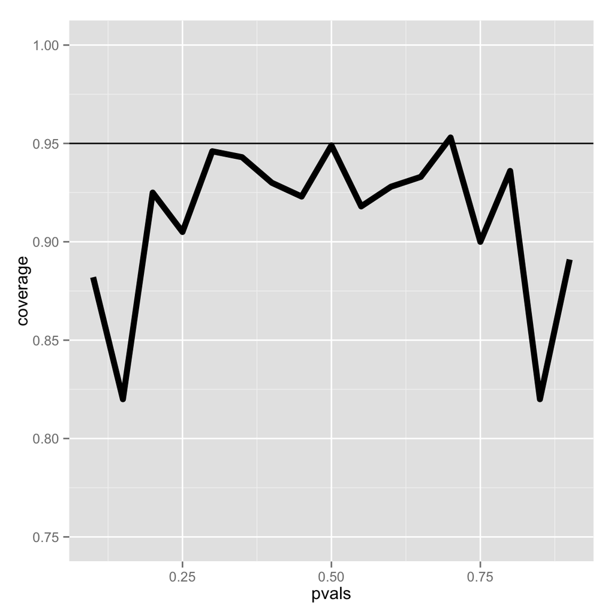

## What’s happening?

- $n$ isn’t large enough for the CLT to be applicable for many of the values of $p$
- Quick fix, form the interval with $\frac{X + 2}{n + 4}$
- (Add two successes and failures, Agresti/Coull interval)

## Simulation

First let’s show that coverage gets better with $n$

```r
n <- 100; pvals <- seq(.1, .9, by = .05); nosim <- 1000
coverage2 <- sapply(pvals, function(p){
  phats <- rbinom(nosim, prob = p, size = n) / n
  ll <- phats - qnorm(.975) * sqrt(phats * (1 - phats) / n)
  ul <- phats + qnorm(.975) * sqrt(phats * (1 - phats) / n)
  mean(ll < p & ul > p)
})
```

## Plot of coverage for $n=100$

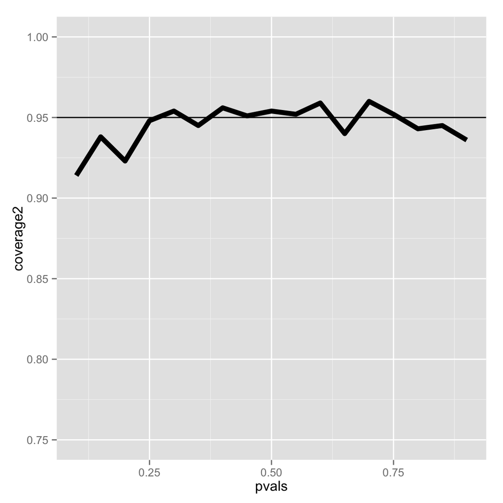

## Simulation

Now let’s look at $n=20$ but adding 2 successes and failures

```r
n <- 20; pvals <- seq(.1, .9, by = .05); nosim <- 1000
coverage <- sapply(pvals, function(p){
  phats <- (rbinom(nosim, prob = p, size = n) + 2) / (n + 4)
  ll <- phats - qnorm(.975) * sqrt(phats * (1 - phats) / n)
  ul <- phats + qnorm(.975) * sqrt(phats * (1 - phats) / n)
  mean(ll < p & ul > p)
})
```

## Adding 2 successes and 2 failures

(It’s a little conservative)

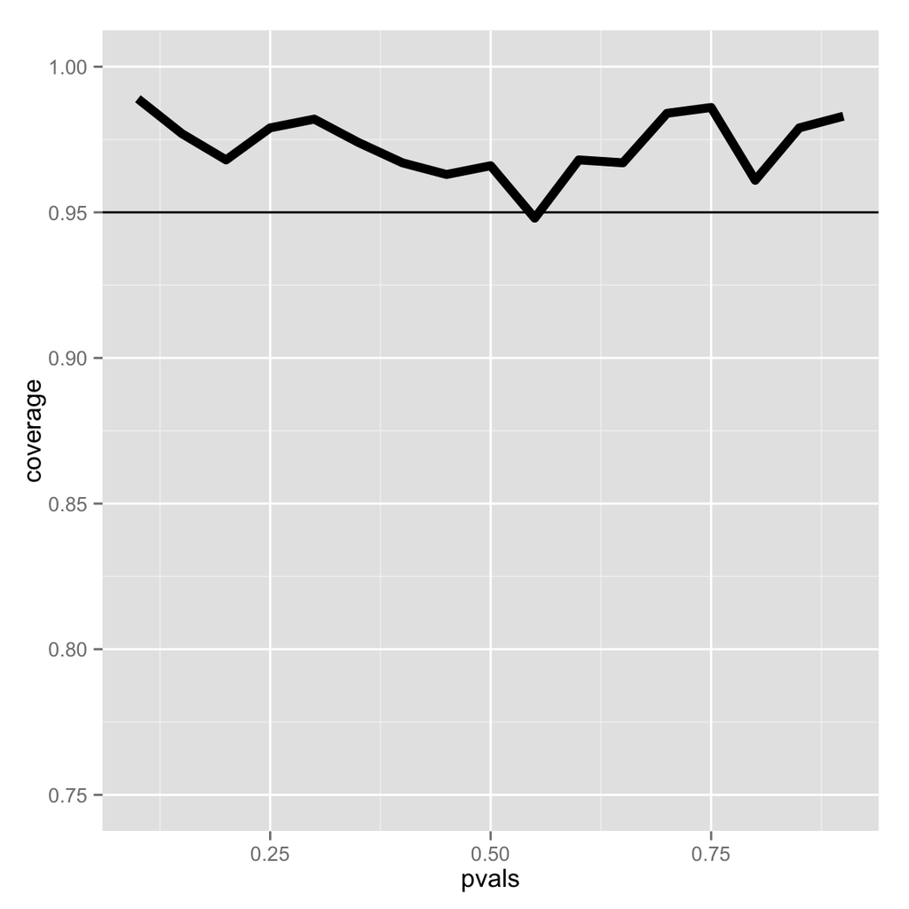

## Poisson interval

- A nuclear pump failed 5 times out of 94.32 days, give a 95% confidence interval for the failure rate per day?
- $X \sim Poisson(\lambda t)$.
- Estimate $\hat \lambda = X/t$
- $Var(\hat \lambda) = \lambda / t$
- $\hat \lambda / t$ is our variance estimate

## R code

```r
x <- 5; t <- 94.32; lambda <- x / t
round(lambda + c(-1, 1) * qnorm(.975) * sqrt(lambda / t), 3)
```

```
## [1] 0.007 0.099
```

```r
poisson.test(x, T = 94.32)$conf
```

```
## [1] 0.01721254 0.12371005
## attr(,"conf.level")
## [1] 0.95
```

## Simulating the Poisson coverage rate

Let’s see how this interval performs for lambda values near what we’re estimating

```r
lambdavals <- seq(0.005, 0.10, by = .01); nosim <- 1000
t <- 100
coverage <- sapply(lambdavals, function(lambda){
  lhats <- rpois(nosim, lambda = lambda * t) / t
  ll <- lhats - qnorm(.975) * sqrt(lhats / t)
  ul <- lhats + qnorm(.975) * sqrt(lhats / t)
  # Find the number of times the true lambda was withing the estimated limits
  mean(ll < lambda & ul > lambda)
})
```

## Covarage

(Gets really bad for small values of lambda)

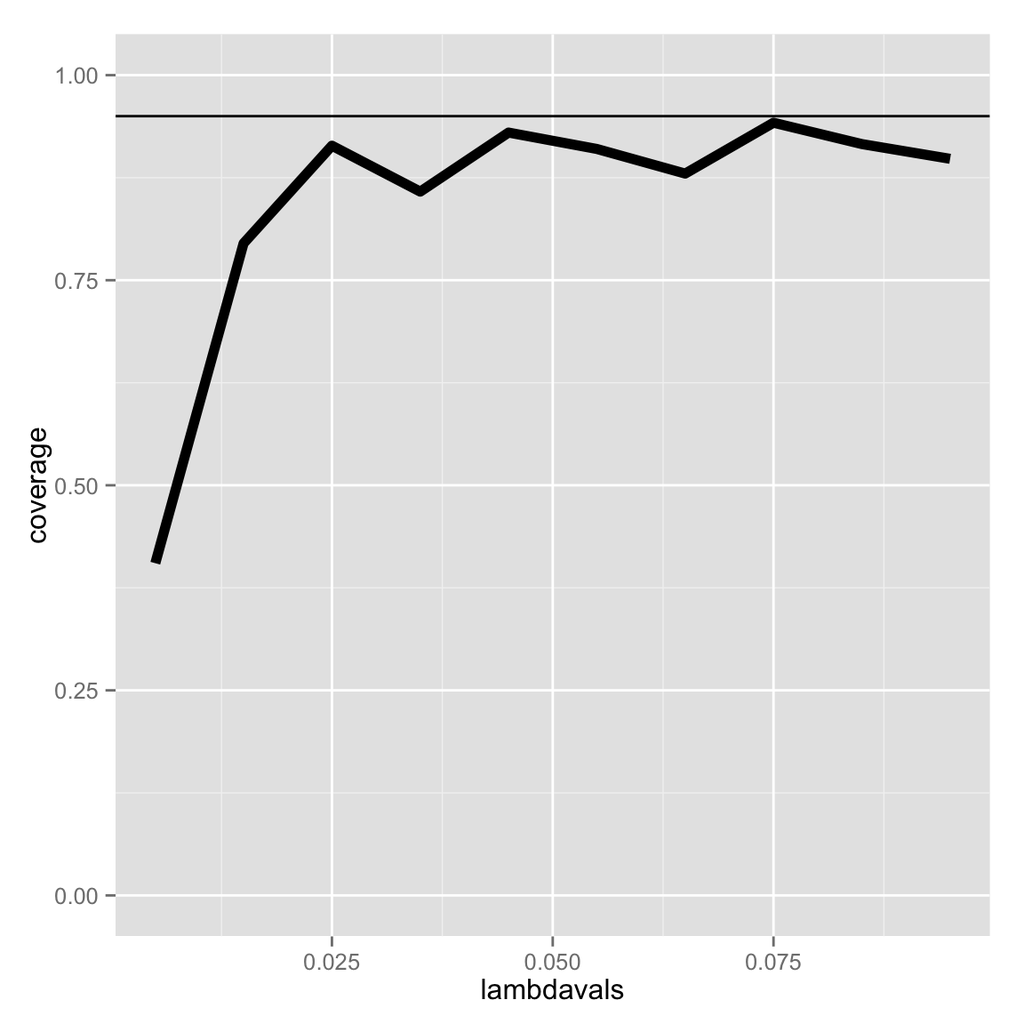

## What if we increase t to 1000?

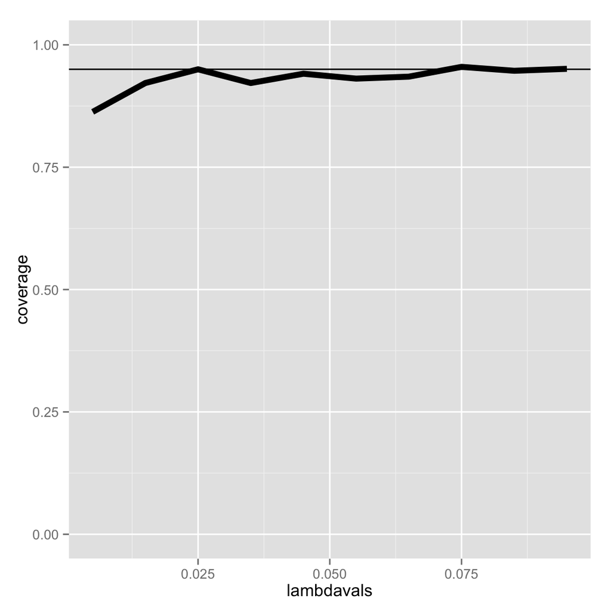

Better coverage, except for small values of lambda.

## Summary

- The LLN states that averages of iid samples converge to the population means that they are estimating
- Poisson rates converge to the rates they are estimating
- The CLT states that averages are approximately normal, with distributions
- centered at the population mean
- with standard deviation equal to the standard error of the mean
- CLT gives no guarantee that $n$ is large enough
- Taking the mean and adding and subtracting the relevant normal quantile times the SE yields a confidence interval for the mean
- Adding and subtracting 2 SEs works for 95% intervals
- Confidence intervals get wider as the coverage increases (why?)
- Confidence intervals get narrower with less variability or larger sample sizes
- The Poisson and binomial case have exact intervals that don’t require the CLT
- But a quick fix for small sample size binomial calculations is to add 2 successes and failures

## Asymptotics

- Asymptotics is the term for the behavior of statistics as the sample size (or some other relevant quantity) limits to infinity (or some other relevant number)
- (Asymptopia is my name for the land of asymptotics, where everything works out well and there’s no messes. The land of infinite data is nice that way.)
- Asymptotics are incredibly useful for simple statistical inference and approximations
- (Not covered in this class) Asymptotics often lead to nice understanding of procedures
- Asymptotics generally give no assurances about finite sample performance
- Asymptotics form the basis for frequency interpretation of probabilities (the long run proportion of times an event occurs)

## Limits of random variables

- Fortunately, for the sample mean there’s a set of powerful results
- These results allow us to talk about the large sample distribution of sample means of a collection of $iid$ observations
- The first of these results we inuitively know
- It says that the average limits to what its estimating, the population mean
- It’s called the Law of Large Numbers
- Example $\bar X_n$ could be the average of the result of $n$ coin flips (i.e. the sample proportion of heads)
  - As we flip a fair coin over and over, it evetually converges to the true probability of a head The LLN forms the basis of frequency style thinking

## Law of large numbers in action

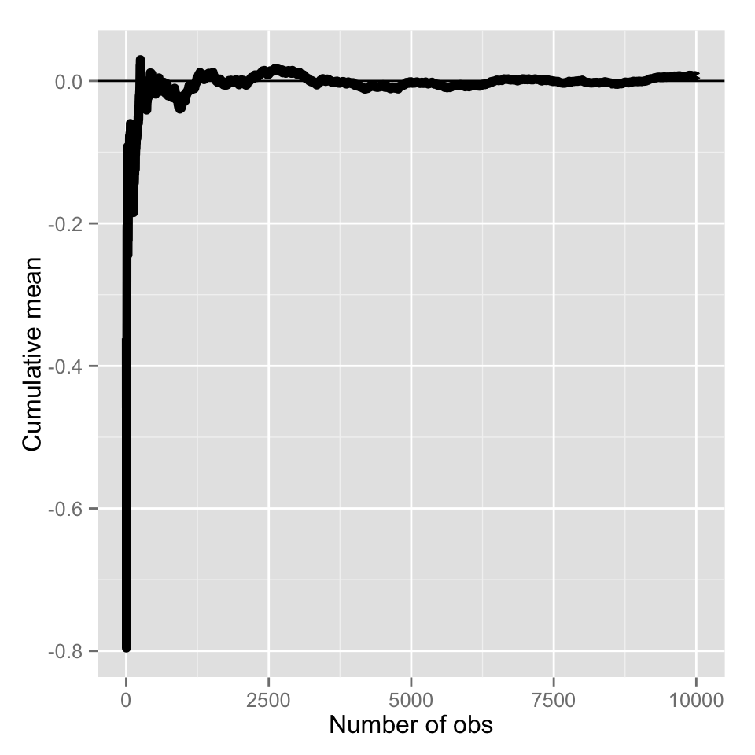

```r
n <- 10000; means <- cumsum(rnorm(n)) / (1  : n); library(ggplot2)
g <- ggplot(data.frame(x = 1 : n, y = means), aes(x = x, y = y))
g <- g + geom_hline(yintercept = 0) + geom_line(size = 2)
g <- g + labs(x = "Number of obs", y = "Cumulative mean")
g
```

## Law of large numbers in action, coin flip

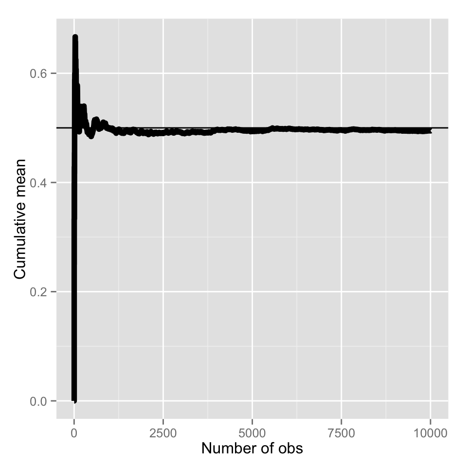

```r
means <- cumsum(sample(0 : 1, n , replace = TRUE)) / (1  : n)
g <- ggplot(data.frame(x = 1 : n, y = means), aes(x = x, y = y))
g <- g + geom_hline(yintercept = 0.5) + geom_line(size = 2)
g <- g + labs(x = "Number of obs", y = "Cumulative mean")
g
```

## Discussion

- An estimator is **consistent** if it converges to what you want to estimate
- The LLN says that the sample mean of iid sample is consistent for the population mean
- Typically, good estimators are consistent; it’s not too much to ask that if we go to the trouble of collecting an infinite amount of data that we get the right answer
- The sample variance and the sample standard deviation of iid random variables are consistent as well

## The Central Limit Theorem

- The **Central Limit Theorem** (CLT) is one of the most important theorems in statistics
- For our purposes, the CLT states that the distribution of averages of iid variables (properly normalized) becomes that of a standard normal as the sample size increases
- The CLT applies in an endless variety of settings
- The result is that $\frac{\bar X_n - \mu}{\sigma / \sqrt{n}}= \frac{\sqrt n (\bar X_n - \mu)}{\sigma} = \frac{\mbox{Estimate} - \mbox{Mean of estimate}}{\mbox{Std. Err. of estimate}}$ has a distribution like that of a standard normal for large $n$.
- (Replacing the standard error by its estimated value doesn’t change the CLT)
- The useful way to think about the CLT is that $\bar X_n$ is approximately $N(\mu, \sigma^2 / n)$

## Example

- Simulate a standard normal random variable by rolling $n$ (six sided)
- Let $X_i$ be the outcome for die $i$
- Then note that $\mu = E[X_i] = 3.5$
- $Var(X_i) = 2.92$
- SE $\sqrt{2.92 / n} = 1.71 / \sqrt{n}$
- Lets roll $n$ dice, take their mean, subtract off 3.5, and divide by $1.71 / \sqrt{n}$ and repeat this over and over

## Result of our die rolling experiment

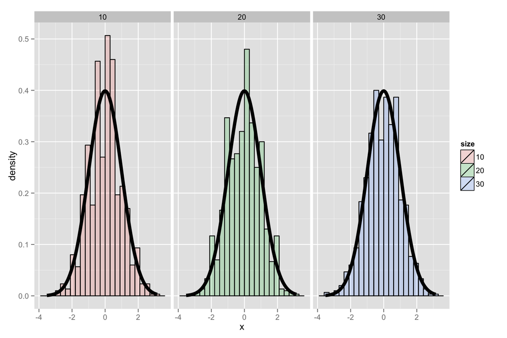

## Coin CLT

- Let $X_i$ be the $0$ or $1$ result of the $i^{th}$ flip of a possibly unfair coin
- The sample proportion, say $\hat p$, is the average of the coin flips
- $E[X_i] = p$ and $Var(X_i) = p(1-p)$
- Standard error of the mean is $\sqrt{p(1-p)/n}$
- Then $\frac{\hat p - p}{\sqrt{p(1-p)/n}}$ will be approximately normally distributed
- Let’s flip a coin $n$ times, take the sample proportion of heads, subtract off .5 and multiply the result by $2 \sqrt{n}$ (divide by $1/(2 \sqrt{n})$)

## Simulation results

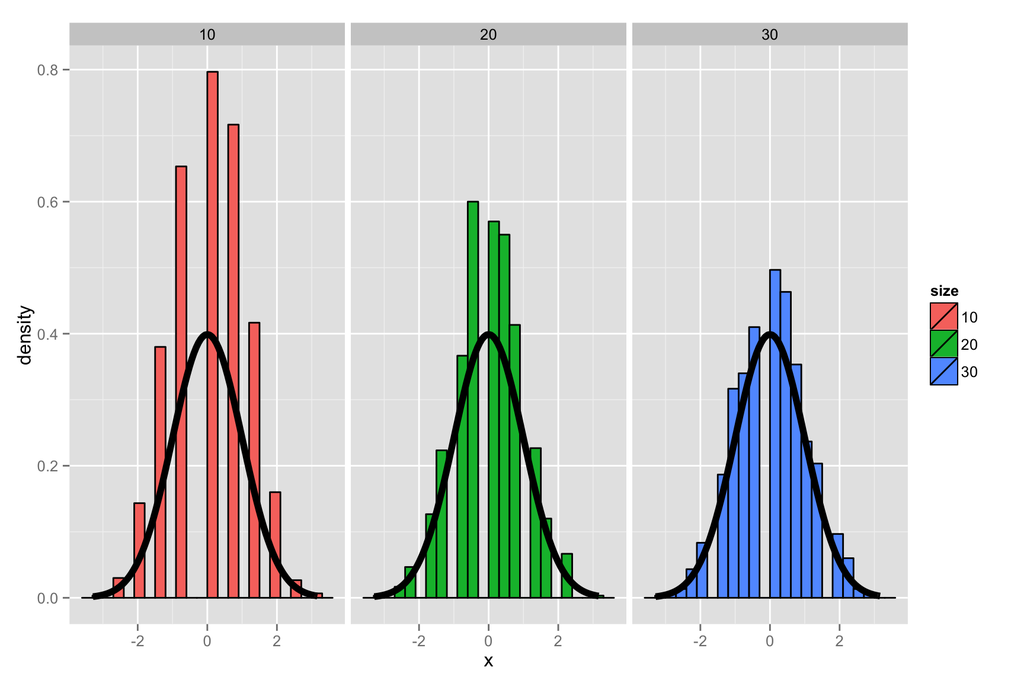

## Simulation results, $p = 0.9$

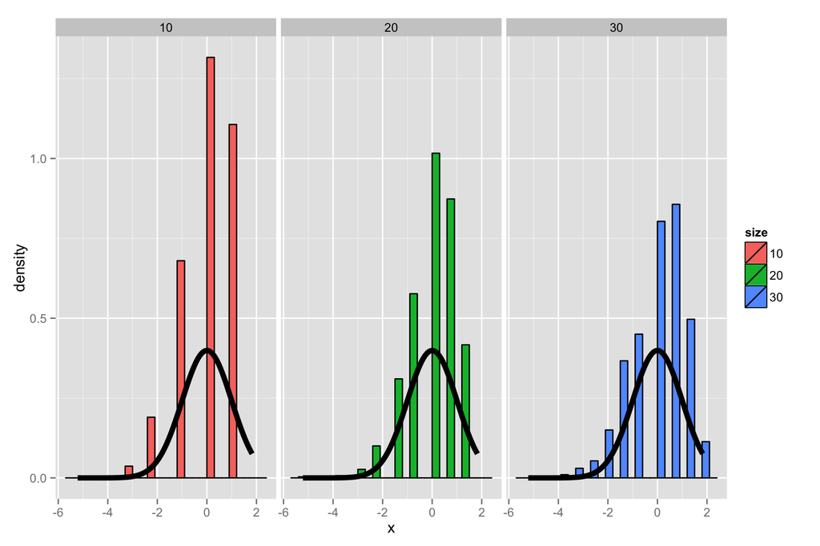

## Galton’s quincunx

http://en.wikipedia.org/wiki/Bean_machine#mediaviewer/File:Quincunx_(Galton_Box)_-_Galton_1889_diagram.png

[figure not shown]

## Confidence intervals

- According to the CLT, the sample mean, $\bar X$, is approximately normal with mean $\mu$ and sd $\sigma / \sqrt{n}$
- $\mu + 2 \sigma /\sqrt{n}$ is pretty far out in the tail (only 2.5% of a normal being larger than 2 sds in the tail)
- Similarly, $\mu - 2 \sigma /\sqrt{n}$ is pretty far in the left tail (only 2.5% chance of a normal being smaller than 2 sds in the tail)
- So the probability $\bar X$ is bigger than $\mu + 2 \sigma / \sqrt{n}$ or smaller than $\mu - 2 \sigma / \sqrt{n}$ is 5%
  - Or equivalently, the probability of being between these limits is 95%
- The quantity $\bar X \pm 2 \sigma /\sqrt{n}$ is called a 95% interval for $\mu$
- The 95% refers to the fact that if one were to repeatly get samples of size $n$, about 95% of the intervals obtained would contain $\mu$
- The 97.5th quantile is 1.96 (so I rounded to 2 above)
- 90% interval you want (100 - 90) / 2 = 5% in each tail
- So you want the 95th percentile (1.645)

## Give a confidence interval for the average height of sons

in Galton’s data

```r
library(UsingR);data(father.son); x <- father.son$sheight
(mean(x) + c(-1, 1) * qnorm(.975) * sd(x) / sqrt(length(x))) / 12
```

```
## [1] 5.709670 5.737674
```

## Sample proportions

- In the event that each $X_i$ is $0$ or $1$ with common success probability $p$ then $\sigma^2 = p(1 - p)$
- The interval takes the form $\hat p \pm z_{1 - \alpha/2} \sqrt{\frac{p(1 - p)}{n}}$
- Replacing $p$ by $\hat p$ in the standard error results in what is called a Wald confidence interval for $p$
- For 95% intervals $\hat p \pm \frac{1}{\sqrt{n}}$ is a quick CI estimate for $p$

## Example

- Your campaign advisor told you that in a random sample of 100 likely voters, 56 intent to vote for you.
- Can you relax? Do you have this race in the bag?
- Without access to a computer or calculator, how precise is this estimate?
- `1/sqrt(100)=0.1` so a back of the envelope calculation gives an approximate 95% interval of `(0.46, 0.66)`
- Not enough for you to relax, better go do more campaigning!
- Rough guidelines, 100 for 1 decimal place, 10,000 for 2, 1,000,000 for 3.

```r
round(1 / sqrt(10 ^ (1 : 6)), 3)
```

```
## [1] 0.316 0.100 0.032 0.010 0.003 0.001
```

## Binomial interval

```r
.56 + c(-1, 1) * qnorm(.975) * sqrt(.56 * .44 / 100)
```

```
## [1] 0.4627099 0.6572901
```

```r
binom.test(56, 100)$conf.int
```

```
## [1] 0.4571875 0.6591640
## attr(,"conf.level")
## [1] 0.95
```

## Simulation

```r
n <- 20; pvals <- seq(.1, .9, by = .05); nosim <- 1000
coverage <- sapply(pvals, function(p){
  phats <- rbinom(nosim, prob = p, size = n) / n
  ll <- phats - qnorm(.975) * sqrt(phats * (1 - phats) / n)
  ul <- phats + qnorm(.975) * sqrt(phats * (1 - phats) / n)
  mean(ll < p & ul > p)
})
```

## Plot of the results (not so good)

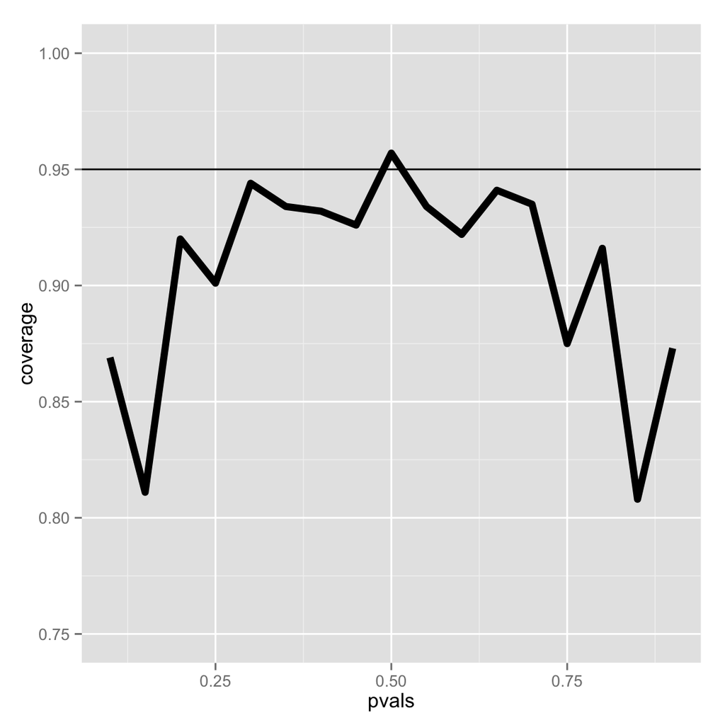

## What’s happening?

- $n$ isn’t large enough for the CLT to be applicable for many of the values of $p$
- Quick fix, form the interval with $\frac{X + 2}{n + 4}$
- (Add two successes and failures, Agresti/Coull interval)

## Simulation

First let’s show that coverage gets better with $n$

```r
n <- 100; pvals <- seq(.1, .9, by = .05); nosim <- 1000
coverage2 <- sapply(pvals, function(p){
  phats <- rbinom(nosim, prob = p, size = n) / n
  ll <- phats - qnorm(.975) * sqrt(phats * (1 - phats) / n)
  ul <- phats + qnorm(.975) * sqrt(phats * (1 - phats) / n)
  mean(ll < p & ul > p)
})
```

## Plot of coverage for $n=100$

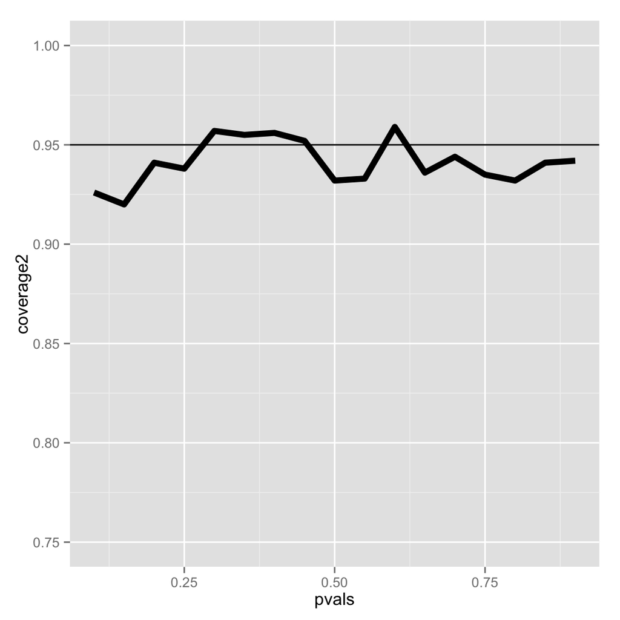

## Simulation

Now let’s look at $n=20$ but adding 2 successes and failures

```r
n <- 20; pvals <- seq(.1, .9, by = .05); nosim <- 1000
coverage <- sapply(pvals, function(p){
  phats <- (rbinom(nosim, prob = p, size = n) + 2) / (n + 4)
  ll <- phats - qnorm(.975) * sqrt(phats * (1 - phats) / n)
  ul <- phats + qnorm(.975) * sqrt(phats * (1 - phats) / n)
  mean(ll < p & ul > p)
})
```

## Adding 2 successes and 2 failures

(It’s a little conservative)

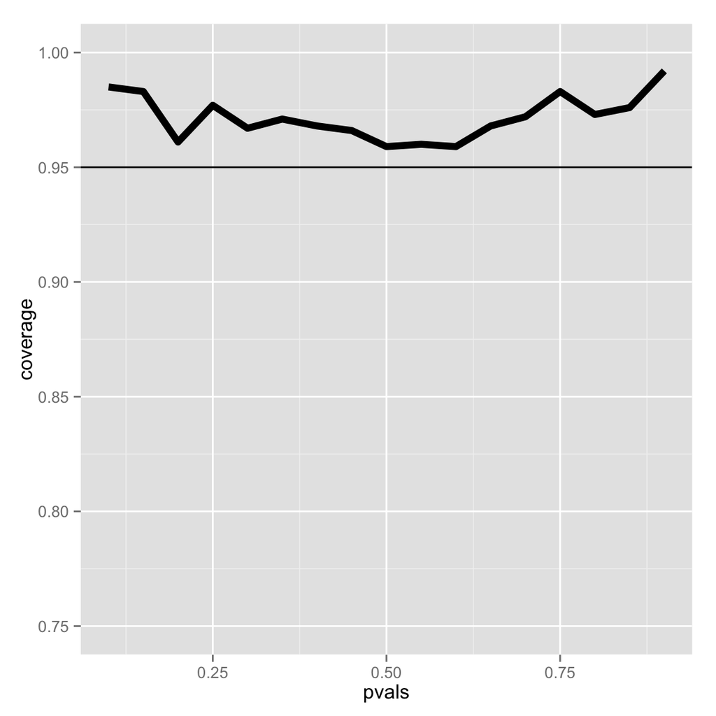

## Poisson interval

- A nuclear pump failed 5 times out of 94.32 days, give a 95% confidence interval for the failure rate per day?
- $X \sim Poisson(\lambda t)$.
- Estimate $\hat \lambda = X/t$
- $Var(\hat \lambda) = \lambda / t$
- $\hat \lambda / t$ is our variance estimate

## R code

```r
x <- 5; t <- 94.32; lambda <- x / t
round(lambda + c(-1, 1) * qnorm(.975) * sqrt(lambda / t), 3)
```

```
## [1] 0.007 0.099
```

```r
poisson.test(x, T = 94.32)$conf
```

```
## [1] 0.01721254 0.12371005
## attr(,"conf.level")
## [1] 0.95
```

## Simulating the Poisson coverage rate

Let’s see how this interval performs for lambda values near what we’re estimating

```r
lambdavals <- seq(0.005, 0.10, by = .01); nosim <- 1000
t <- 100
coverage <- sapply(lambdavals, function(lambda){
  lhats <- rpois(nosim, lambda = lambda * t) / t
  ll <- lhats - qnorm(.975) * sqrt(lhats / t)
  ul <- lhats + qnorm(.975) * sqrt(lhats / t)
  mean(ll < lambda & ul > lambda)
})
```

## Covarage

(Gets really bad for small values of lambda)

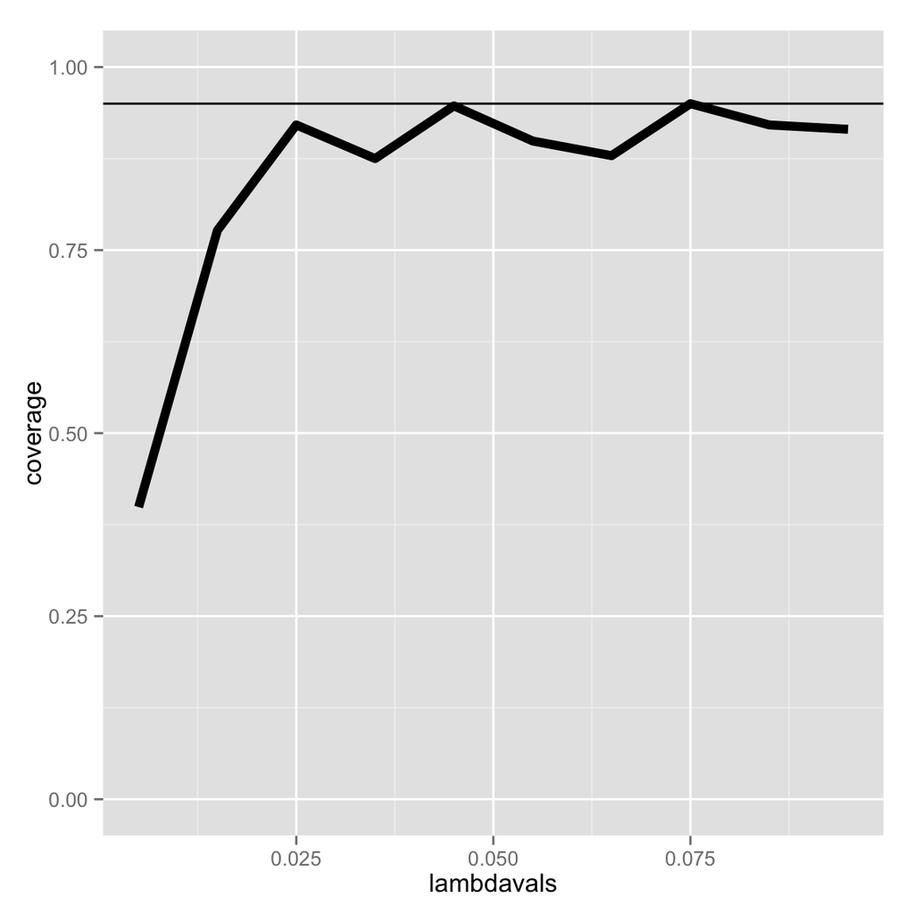

## What if we increase t to 1000?

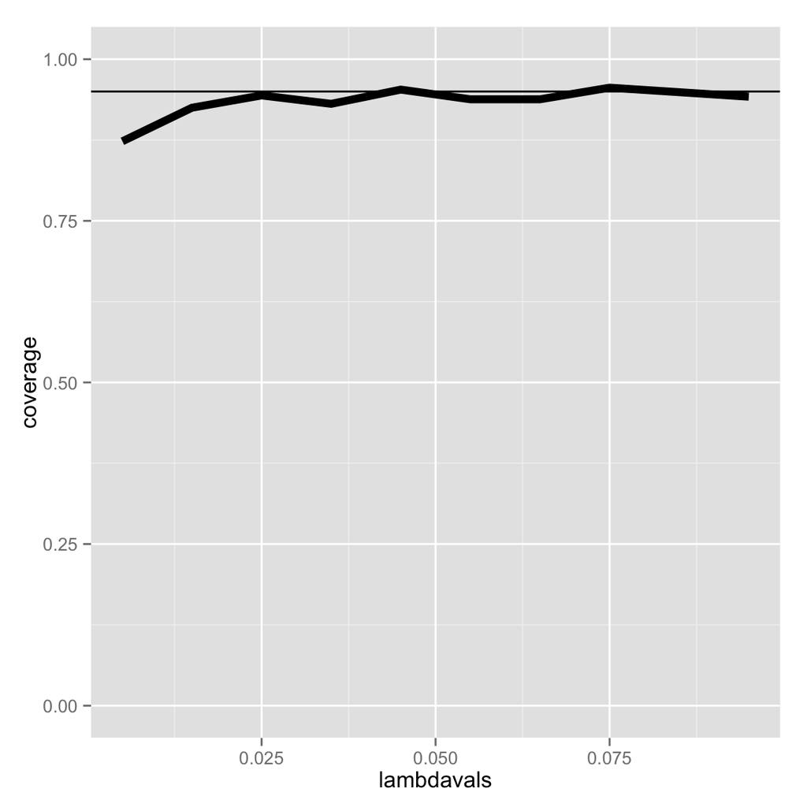

## Summary

- The LLN states that averages of iid samples converge to the population means that they are estimating
- The CLT states that averages are approximately normal, with distributions
- centered at the population mean
- with standard deviation equal to the standard error of the mean
- CLT gives no guarantee that $n$ is large enough
- Taking the mean and adding and subtracting the relevant normal quantile times the SE yields a confidence interval for the mean
- Adding and subtracting 2 SEs works for 95% intervals
- Confidence intervals get wider as the coverage increases (why?)
- Confidence intervals get narrower with less variability or larger sample sizes
- The Poisson and binomial case have exact intervals that don’t require the CLT
- But a quick fix for small sample size binomial calculations is to add 2 successes and failures